# Analyse des données de consommations d’énergie en Inde

### Pour l’ensemble des Etats

Lissage par moindre carrés pénalisés

On fait l’ajustement pour différentes valeurs de lambda pour minimiser le critère de pénalité.  
On veut la fonction la plus proche des points et la moins oscillante grâce à la pénalité

```r
# Initialisation d'une grille de lambda
gcv = rep(0,30)

for (i in 1:30){
  lambda = exp(i-10)
  fdpar = fdPar(splbasis,Lfdobj = 4,lambda=lambda)
  smoothdata = smooth.basis(tps,as.matrix(data_long[,c(-1)]), fdParobj = fdpar)
  gcv[i] = mean(smoothdata$gcv)
}
plot(gcv)
which.min(gcv)
```

[output not shown]

Nous allons recalculer la pénalité et refaire le lissage avec la valeur de lambda minimale :

```r
lambda = exp(which.min(gcv)-10)
fdpar = fdPar(splbasis,Lfdobj = 4,lambda=lambda) # calcul pénalité
smoothdata = smooth.basis(tps,as.matrix(data_long[,c(-1)]),fdParobj = fdpar) # lissage
```

Nous évaluons notre objet fonctionnel à chaque point de temps :

```r
fhatsmooth <- eval.fd(tps, smoothdata$fd)
```

Représentation pour l’ensemble des Etats

Nous représentons les observations et la fonction estimée reconstruite ˆf.

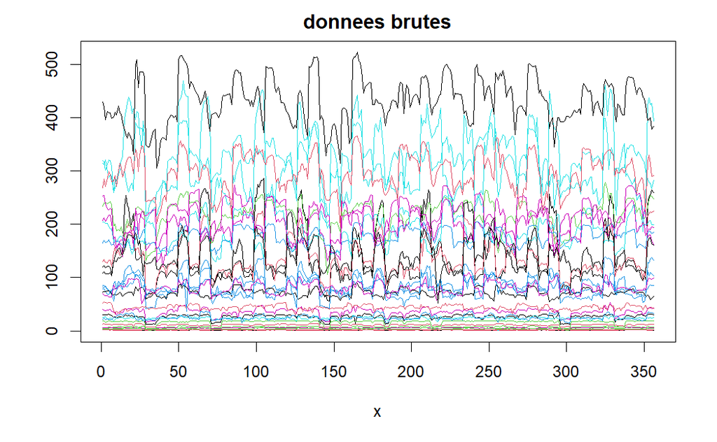

```r
matplot(tps,data_long[,c(-1)],type="l",lty=1,ylab="",main="donnees brutes")
```

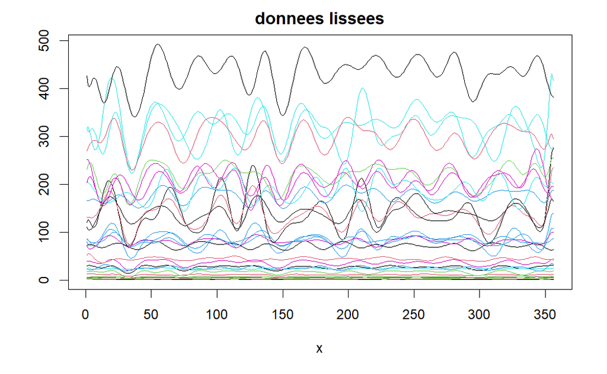

```r
matplot(tps,fhatsmooth,type="l",lty=1,ylab="",main="donnees lissees")
```

Nous obtenons des courbes lissées, moins irrégulières, qui explique bien la tendance de la consommation d’énergie pour chacun des Etats.

Lors de la création de notre base de spline, nous avons choisi 35 coupures, ce qui biaise forcément notre analyse. Avec ces courbes lissées, les analyses ne sont pas exhaustives pour éviter le sur-apprentissage. Avec ces courbes, nous pouvons supposer qu’il y a plus de variabilité en hiver qu’en été.

Nous représentons maintenant la dérivée première et seconde pour étudier les vitesses de croissance et les accélérations de croissance.

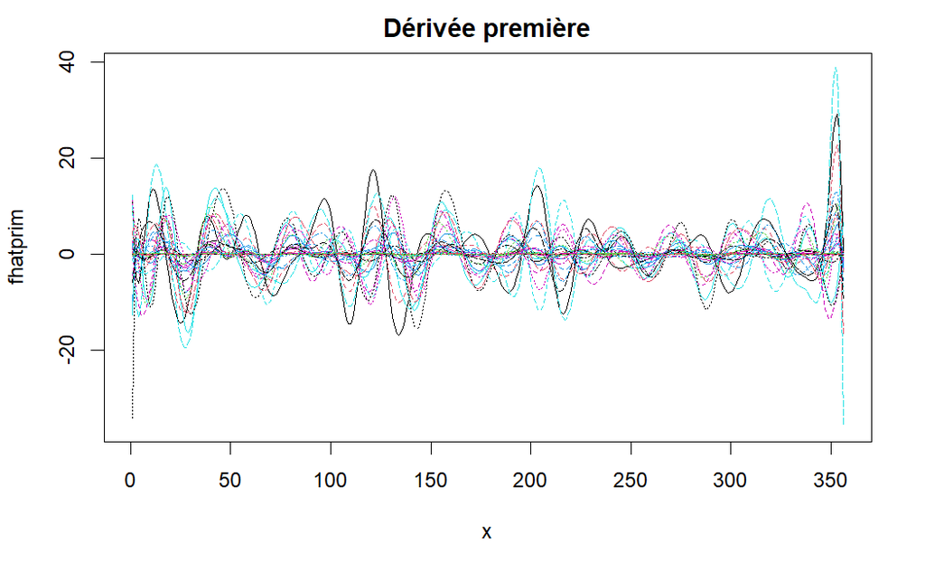

```r
fhatprim = eval.fd(tps,smoothdata$fd,Lfdobj=1) # dérivé première
fhatpprim = eval.fd(tps,smoothdata$fd,Lfdobj=2) # dérivé seconde
matplot(tps,
        fhatprim,
        type="l",
        main = "Dérivée première")
```

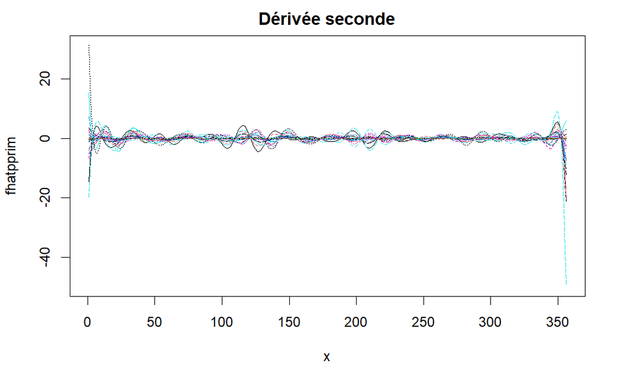

```r
matplot(tps, fhatpprim, type = "l",
        main = "Dérivée seconde")
```